# 11_18_meeting_report

Siyang Ni

2022-11-18

## Note

For every variable, *Column %(NA-)* reports the frequency without any NAs. I also reported the cumulative frequency in column cum.%(NA-).

I also plotted the frequency for each variable, giving a more intuitive way of digesting the frequency information. All NAs are indicated by the “last” bar of the histogram, unless otherwise indicated.

## Loading datasets

```r
setwd("D:/research/Monitoring-The-Future/mtf_19_12")

load("D:/research/Monitoring-The-Future/mtf_19_12/DS0001/37841-0001-Data.rda")
core <- da37841.0001
rm(da37841.0001)

load("D:/research/Monitoring-The-Future/mtf_19_12/DS0002/37841-0002-Data.rda")
ds2 <- da37841.0002
rm(da37841.0002)

load("D:/research/Monitoring-The-Future/mtf_19_12/DS0003/37841-0003-Data.rda")
ds3 <- da37841.0003
rm(da37841.0003)

load("D:/research/Monitoring-The-Future/mtf_19_12/DS0004/37841-0004-Data.rda")
ds4 <- da37841.0004
rm(da37841.0004)

load("D:/research/Monitoring-The-Future/mtf_19_12/DS0005/37841-0005-Data.rda")
ds5 <- da37841.0005
rm(da37841.0005)

load("D:/research/Monitoring-The-Future/mtf_19_12/DS0006/37841-0006-Data.rda")
ds6 <- da37841.0006
rm(da37841.0006)

load("D:/research/Monitoring-The-Future/mtf_19_12/DS0007/37841-0007-Data.rda")
ds7 <- da37841.0007
rm(da37841.0007)

load("D:/research/Monitoring-The-Future/mtf_19_12/DS0008/37841-0008-Data.rda")
ds8 <- da37841.0008
rm(da37841.0008)

load("D:/research/Monitoring-The-Future/mtf_19_12/DS0009/37841-0009-Data.rda")
ds9 <- da37841.0009
rm(da37841.0009)
```

## Delinquency Variables

Load relevant packages

```r
library(epiDisplay)
```

### 00650:#X/12MO R TCKTD

Within the LAST 12 MONTHS, how many times, if any, have you received a ticket (OR been stopped and warned) for moving violations, such as speeding, running a stop light, or improper passing?

0=“None” 1=“Once” 2=“Twice” 3=“Three times” 4=“Four or more times”

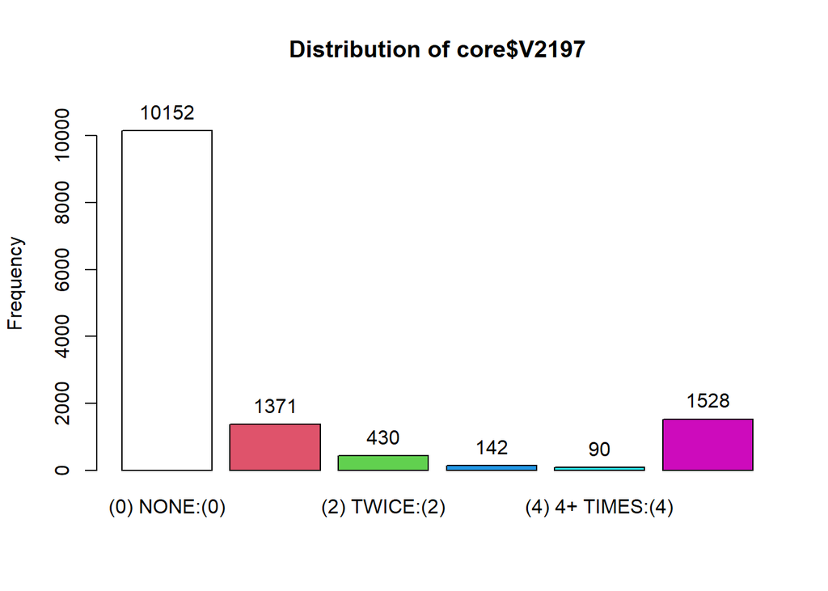

```
## core$V2197 :
##                  Frequency   %(NA+) cum.%(NA+)   %(NA-) cum.%(NA-)
## (0) NONE:(0)         10152     74.0       74.0     83.3       83.3
## (1) ONCE:(1)          1371     10.0       84.0     11.3       94.6
## (2) TWICE:(2)          430      3.1       87.2      3.5       98.1
## (3) 3 TIMES:(3)        142      1.0       88.2      1.2       99.3
## (4) 4+ TIMES:(4)        90      0.7       88.9      0.7      100.0
## NA's                  1528     11.1      100.0      0.0      100.0
##   Total              13713    100.0      100.0    100.0      100.0
```

```r
tab1(core$V2197, cum.percent = TRUE)
```

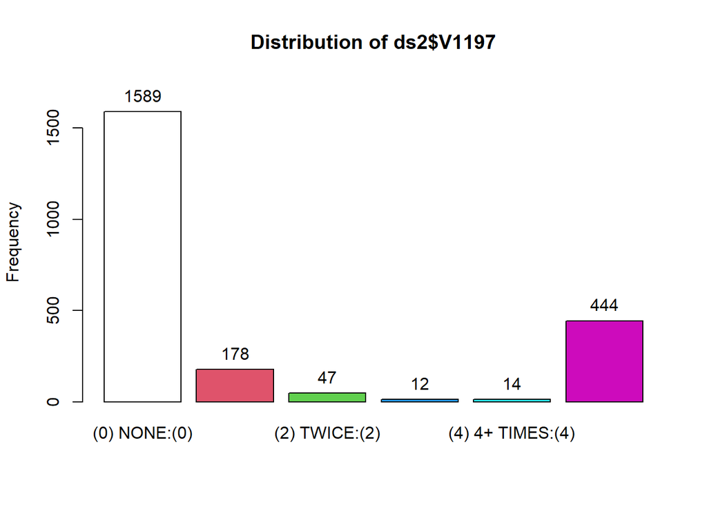

```
## ds2$V1197 :
##                  Frequency   %(NA+) cum.%(NA+)   %(NA-) cum.%(NA-)
## (0) NONE:(0)          1589     69.6       69.6     86.4       86.4
## (1) ONCE:(1)           178      7.8       77.4      9.7       96.0
## (2) TWICE:(2)           47      2.1       79.4      2.6       98.6
## (3) 3 TIMES:(3)         12      0.5       79.9      0.7       99.2
## (4) 4+ TIMES:(4)        14      0.6       80.6      0.8      100.0
## NA's                   444     19.4      100.0      0.0      100.0
##   Total               2284    100.0      100.0    100.0      100.0
```

```r
tab1(ds2$V1197, cum.percent = TRUE)
```

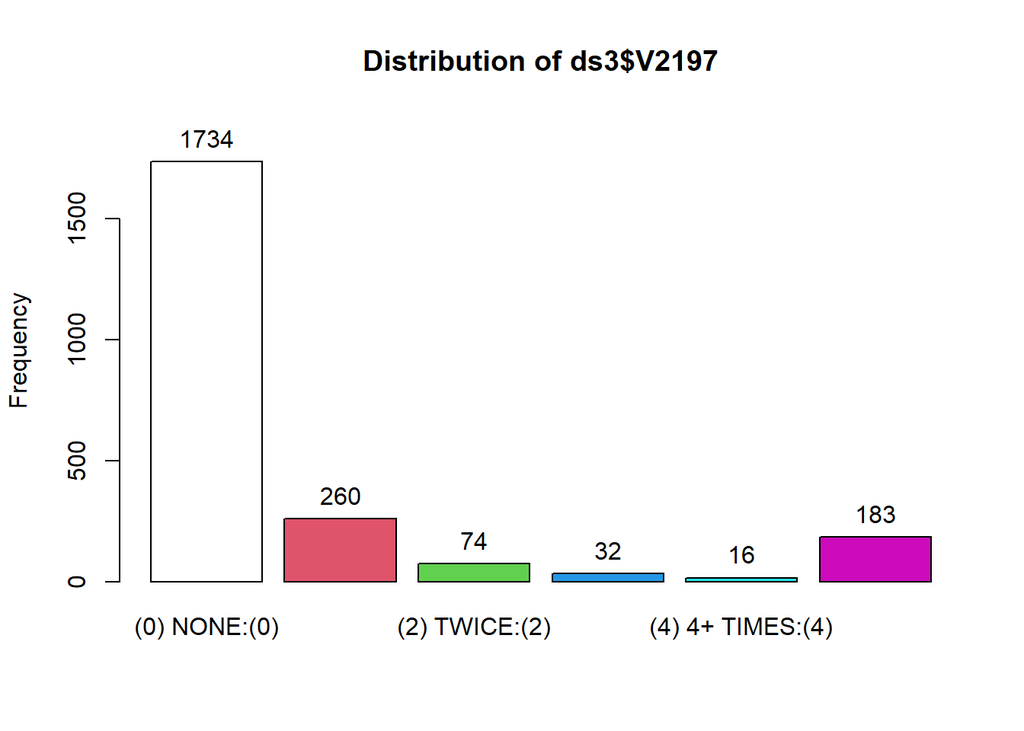

```
## ds3$V2197 :
##                  Frequency   %(NA+) cum.%(NA+)   %(NA-) cum.%(NA-)
## (0) NONE:(0)          1734     75.4       75.4     81.9       81.9
## (1) ONCE:(1)           260     11.3       86.7     12.3       94.2
## (2) TWICE:(2)           74      3.2       90.0      3.5       97.7
## (3) 3 TIMES:(3)         32      1.4       91.3      1.5       99.2
## (4) 4+ TIMES:(4)        16      0.7       92.0      0.8      100.0
## NA's                   183      8.0      100.0      0.0      100.0
##   Total               2299    100.0      100.0    100.0      100.0
```

```r
tab1(ds3$V2197, cum.percent = TRUE)
```

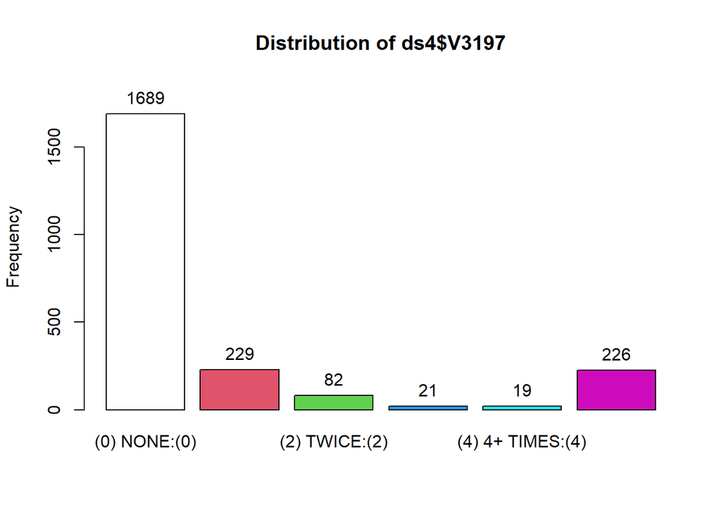

```
## ds4$V3197 :
##                  Frequency   %(NA+) cum.%(NA+)   %(NA-) cum.%(NA-)
## (0) NONE:(0)          1689     74.5       74.5     82.8       82.8
## (1) ONCE:(1)           229     10.1       84.6     11.2       94.0
## (2) TWICE:(2)           82      3.6       88.3      4.0       98.0
## (3) 3 TIMES:(3)         21      0.9       89.2      1.0       99.1
## (4) 4+ TIMES:(4)        19      0.8       90.0      0.9      100.0
## NA's                   226     10.0      100.0      0.0      100.0
##   Total               2266    100.0      100.0    100.0      100.0
```

```r
tab1(ds4$V3197, cum.percent = TRUE)
```

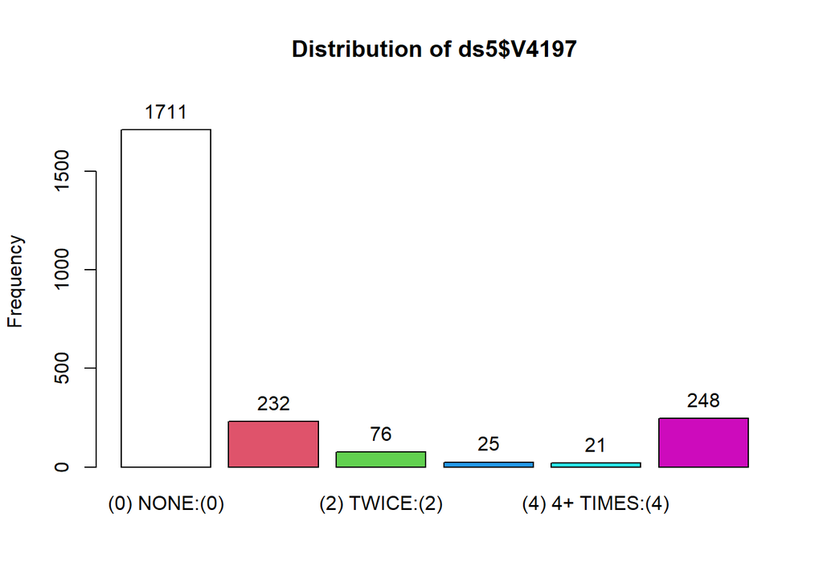

```
## ds5$V4197 :
##                  Frequency   %(NA+) cum.%(NA+)   %(NA-) cum.%(NA-)
## (0) NONE:(0)          1711     74.0       74.0     82.9       82.9
## (1) ONCE:(1)           232     10.0       84.0     11.2       94.1
## (2) TWICE:(2)           76      3.3       87.3      3.7       97.8
## (3) 3 TIMES:(3)         25      1.1       88.4      1.2       99.0
## (4) 4+ TIMES:(4)        21      0.9       89.3      1.0      100.0
## NA's                   248     10.7      100.0      0.0      100.0
##   Total               2313    100.0      100.0    100.0      100.0
```

```r
tab1(ds5$V4197, cum.percent = TRUE)
```

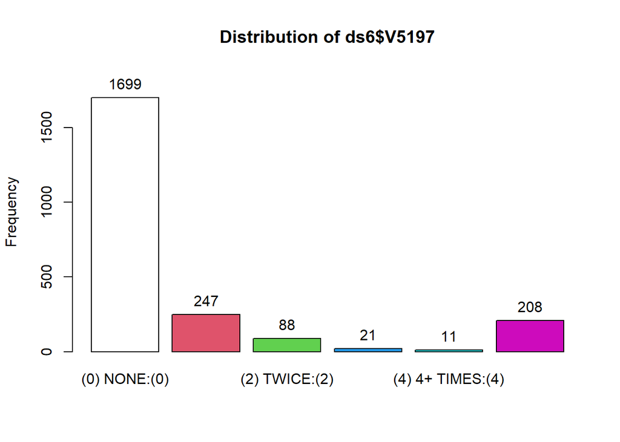

```
## ds6$V5197 :
##                  Frequency   %(NA+) cum.%(NA+)   %(NA-) cum.%(NA-)
## (0) NONE:(0)          1699     74.7       74.7     82.2       82.2
## (1) ONCE:(1)           247     10.9       85.6     12.0       94.2
## (2) TWICE:(2)           88      3.9       89.4      4.3       98.5
## (3) 3 TIMES:(3)         21      0.9       90.4      1.0       99.5
## (4) 4+ TIMES:(4)        11      0.5       90.9      0.5      100.0
## NA's                   208      9.1      100.0      0.0      100.0
##   Total               2274    100.0      100.0    100.0      100.0
```

```r
tab1(ds6$V5197, cum.percent = TRUE)
```

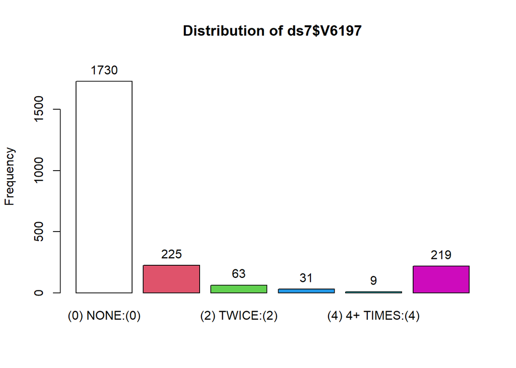

```
## ds7$V6197 :
##                  Frequency   %(NA+) cum.%(NA+)   %(NA-) cum.%(NA-)
## (0) NONE:(0)          1730     76.0       76.0     84.1       84.1
## (1) ONCE:(1)           225      9.9       85.9     10.9       95.0
## (2) TWICE:(2)           63      2.8       88.6      3.1       98.1
## (3) 3 TIMES:(3)         31      1.4       90.0      1.5       99.6
## (4) 4+ TIMES:(4)         9      0.4       90.4      0.4      100.0
## NA's                   219      9.6      100.0      0.0      100.0
##   Total               2277    100.0      100.0    100.0      100.0
```

```r
tab1(ds7$V6197, cum.percent = TRUE)
```

### 06520:FRQ FIGHT PARNTS

how often have you . . . argued or had a fight with either of your parents?

1=“Not At All” 2=“Once” 3=“Twice” 4=“3 or 4 Times” 5=“5 or More Times” Data from the Western Region intentionally obliterated.

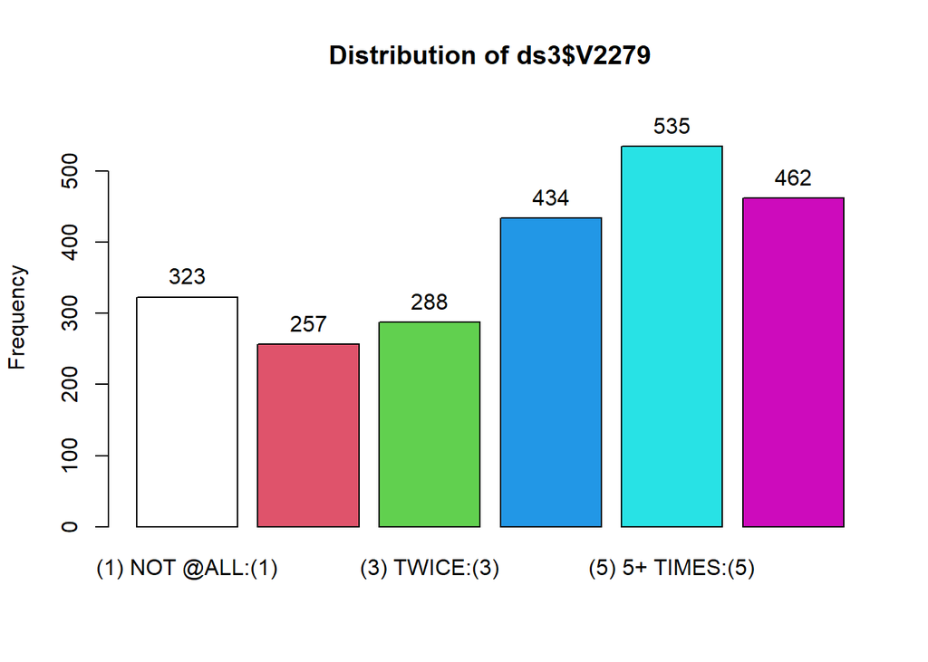

```
## ds3$V2279 :
##                  Frequency   %(NA+) cum.%(NA+)   %(NA-) cum.%(NA-)
## (1) NOT @ALL:(1)       323     14.0       14.0     17.6       17.6
## (2) ONCE:(2)           257     11.2       25.2     14.0       31.6
## (3) TWICE:(3)          288     12.5       37.8     15.7       47.3
## (4) 3-4TIMES:(4)       434     18.9       56.6     23.6       70.9
## (5) 5+ TIMES:(5)       535     23.3       79.9     29.1      100.0
## NA's                   462     20.1      100.0      0.0      100.0
##   Total               2299    100.0      100.0    100.0      100.0
```

```r
tab1(ds3$V2279, cum.percent = TRUE)
```

### 06530:FRQ HIT SUPRVISR

During the LAST 12 MONTHS, how often have you . . . hit an instructor or supervisor?

1=“Not At All” 2=“Once” 3=“Twice” 4=“3 or 4 Times” 5=“5 or More Times”

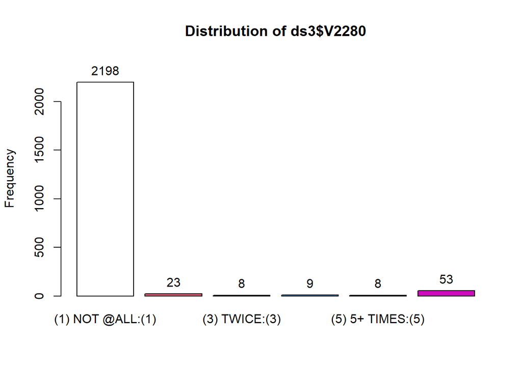

```
## ds3$V2280 :
##                  Frequency   %(NA+) cum.%(NA+)   %(NA-) cum.%(NA-)
## (1) NOT @ALL:(1)      2198     95.6       95.6     97.9       97.9
## (2) ONCE:(2)            23      1.0       96.6      1.0       98.9
## (3) TWICE:(3)            8      0.3       97.0      0.4       99.2
## (4) 3-4TIMES:(4)         9      0.4       97.3      0.4       99.6
## (5) 5+ TIMES:(5)         8      0.3       97.7      0.4      100.0
## NA's                    53      2.3      100.0      0.0      100.0
##   Total               2299    100.0      100.0    100.0      100.0
```

```r
tab1(ds3$V2280, cum.percent = TRUE)
```

### 06540:FRQ FGT WRK/SCHL

During the LAST 12 MONTHS, how often have you . . . gotten into a serious fight in school or at work?

1=“Not At All” 2=“Once” 3=“Twice” 4=“3 or 4 Times” 5=“5 or More Times”

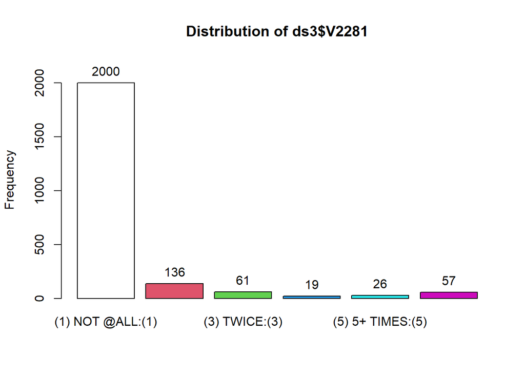

```
## ds3$V2281 :
##                  Frequency   %(NA+) cum.%(NA+)   %(NA-) cum.%(NA-)
## (1) NOT @ALL:(1)      2000     87.0       87.0     89.2       89.2
## (2) ONCE:(2)           136      5.9       92.9      6.1       95.3
## (3) TWICE:(3)           61      2.7       95.6      2.7       98.0
## (4) 3-4TIMES:(4)        19      0.8       96.4      0.8       98.8
## (5) 5+ TIMES:(5)        26      1.1       97.5      1.2      100.0
## NA's                    57      2.5      100.0      0.0      100.0
##   Total               2299    100.0      100.0    100.0      100.0
```

```r
tab1(ds3$V2281, cum.percent = TRUE)
```

### 06550:FRQ GANG FIGHT

During the LAST 12 MONTHS, how often have you . . . taken part in a fight where a group of your friends were against another group?

1=“Not At All” 2=“Once” 3=“Twice” 4=“3 or 4 Times” 5=“5 or More Times”

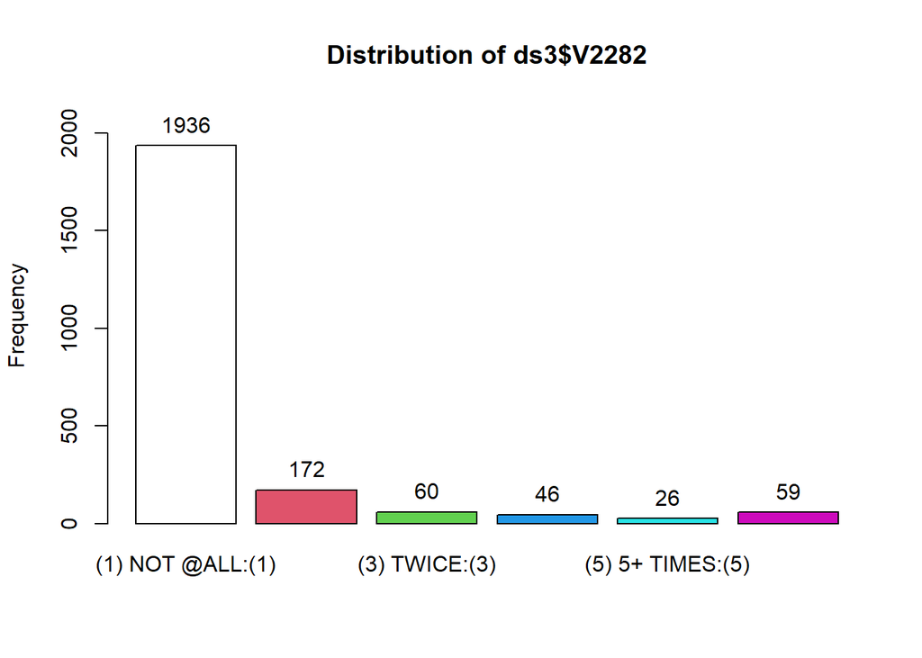

```
## ds3$V2282 :
##                  Frequency   %(NA+) cum.%(NA+)   %(NA-) cum.%(NA-)
## (1) NOT @ALL:(1)      1936     84.2       84.2     86.4       86.4
## (2) ONCE:(2)           172      7.5       91.7      7.7       94.1
## (3) TWICE:(3)           60      2.6       94.3      2.7       96.8
## (4) 3-4TIMES:(4)        46      2.0       96.3      2.1       98.8
## (5) 5+ TIMES:(5)        26      1.1       97.4      1.2      100.0
## NA's                    59      2.6      100.0      0.0      100.0
##   Total               2299    100.0      100.0    100.0      100.0
```

```r
tab1(ds3$V2282, cum.percent = TRUE)
```

### 06560:FRQ HURT SM1 BAD

During the LAST 12 MONTHS, how often have you . . . hurt someone badly enough to need bandages or a doctor?

1=“Not At All” 2=“Once” 3=“Twice” 4=“3 or 4 Times” 5=“5 or More Times”

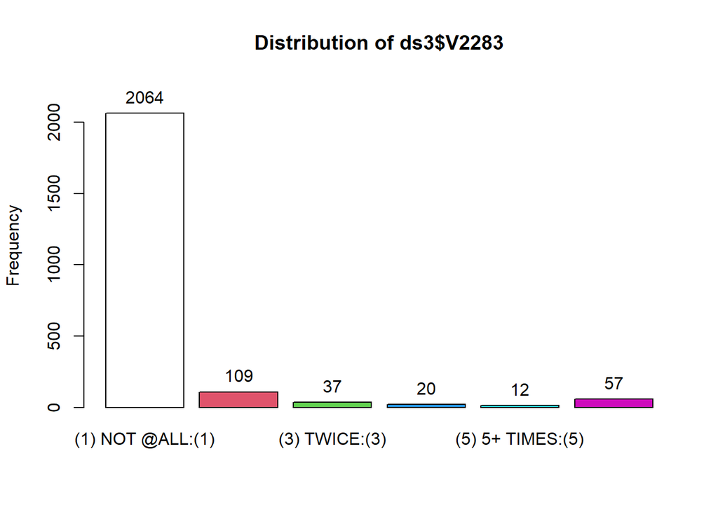

```
## ds3$V2283 :
##                  Frequency   %(NA+) cum.%(NA+)   %(NA-) cum.%(NA-)
## (1) NOT @ALL:(1)      2064     89.8       89.8     92.1       92.1
## (2) ONCE:(2)           109      4.7       94.5      4.9       96.9
## (3) TWICE:(3)           37      1.6       96.1      1.7       98.6
## (4) 3-4TIMES:(4)        20      0.9       97.0      0.9       99.5
## (5) 5+ TIMES:(5)        12      0.5       97.5      0.5      100.0
## NA's                    57      2.5      100.0      0.0      100.0
##   Total               2299    100.0      100.0    100.0      100.0
```

```r
tab1(ds3$V2283, cum.percent = TRUE)
```

### 06570:FRQ THREAT WEAPN

During the LAST 12 MONTHS, how often have you . . . used a knife or gun or some other thing (like a club) to get something from a person?

1=“Not At All” 2=“Once” 3=“Twice” 4=“3 or 4 Times” 5=“5 or More Times”

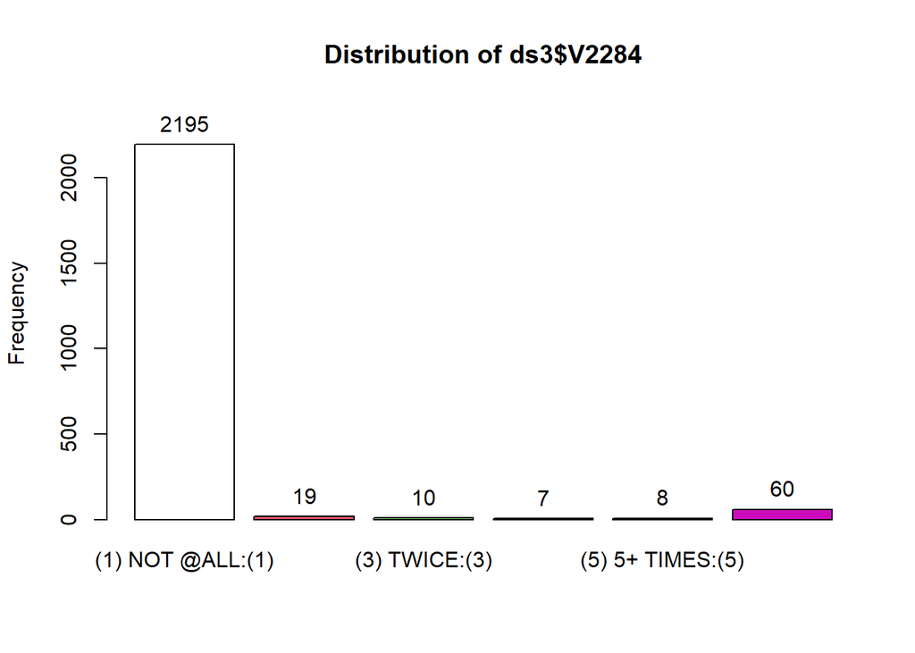

```
## ds3$V2284 :
##                  Frequency   %(NA+) cum.%(NA+)   %(NA-) cum.%(NA-)
## (1) NOT @ALL:(1)      2195     95.5       95.5     98.0       98.0
## (2) ONCE:(2)            19      0.8       96.3      0.8       98.9
## (3) TWICE:(3)           10      0.4       96.7      0.4       99.3
## (4) 3-4TIMES:(4)         7      0.3       97.0      0.3       99.6
## (5) 5+ TIMES:(5)         8      0.3       97.4      0.4      100.0
## NA's                    60      2.6      100.0      0.0      100.0
##   Total               2299    100.0      100.0    100.0      100.0
```

```r
tab1(ds3$V2284, cum.percent = TRUE)
```

### 06580:FRQ STEAL <$50

During the LAST 12 MONTHS, how often have you . . . taken something not belonging to you worth under $50?

1=“Not At All” 2=“Once” 3=“Twice” 4=“3 or 4 Times” 5=“5 or More Times”

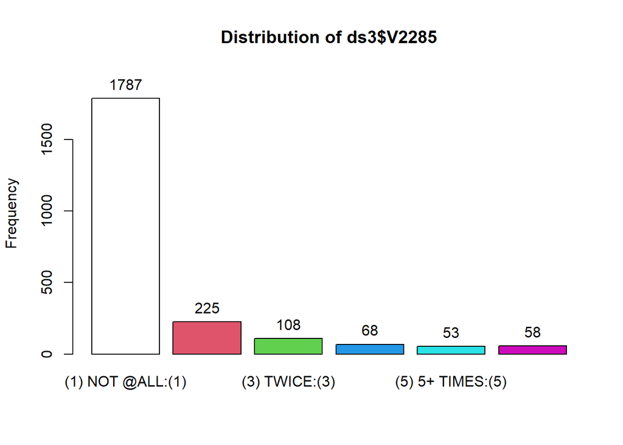

```
## ds3$V2285 :
##                  Frequency   %(NA+) cum.%(NA+)   %(NA-) cum.%(NA-)
## (1) NOT @ALL:(1)      1787     77.7       77.7     79.7       79.7
## (2) ONCE:(2)           225      9.8       87.5     10.0       89.8
## (3) TWICE:(3)          108      4.7       92.2      4.8       94.6
## (4) 3-4TIMES:(4)        68      3.0       95.2      3.0       97.6
## (5) 5+ TIMES:(5)        53      2.3       97.5      2.4      100.0
## NA's                    58      2.5      100.0      0.0      100.0
##   Total               2299    100.0      100.0    100.0      100.0
```

```r
tab1(ds3$V2285, cum.percent = TRUE)
```

### 06590:FRQ STEAL >$50

During the LAST 12 MONTHS, how often have you . . . taken something not belonging to you worth over $50?

1=“Not At All” 2=“Once” 3=“Twice” 4=“3 or 4 Times” 5=“5 or More Times”

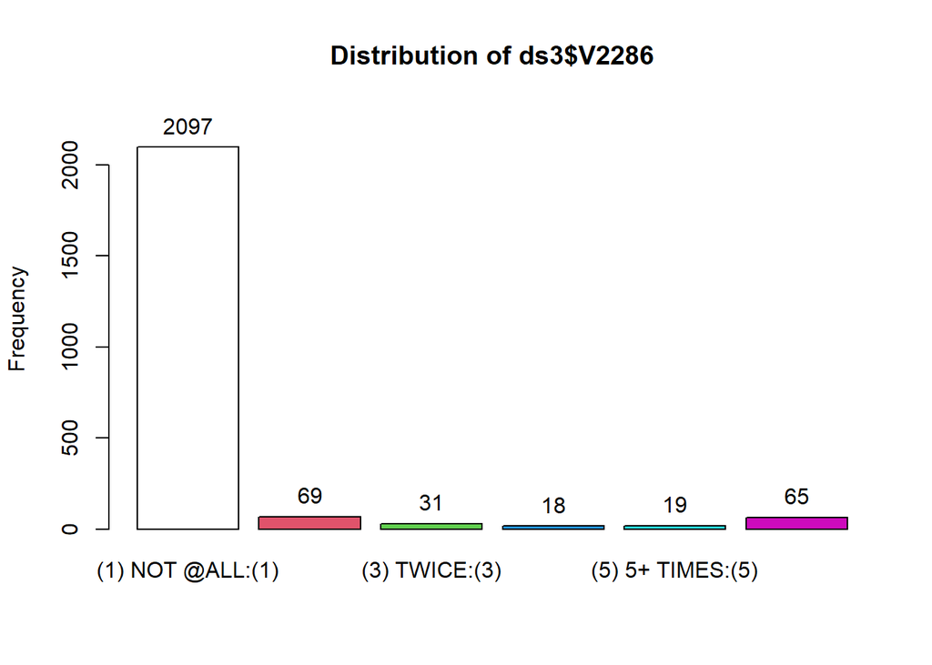

```
## ds3$V2286 :
##                  Frequency   %(NA+) cum.%(NA+)   %(NA-) cum.%(NA-)
## (1) NOT @ALL:(1)      2097     91.2       91.2     93.9       93.9
## (2) ONCE:(2)            69      3.0       94.2      3.1       97.0
## (3) TWICE:(3)           31      1.3       95.6      1.4       98.3
## (4) 3-4TIMES:(4)        18      0.8       96.3      0.8       99.1
## (5) 5+ TIMES:(5)        19      0.8       97.2      0.9      100.0
## NA's                    65      2.8      100.0      0.0      100.0
##   Total               2299    100.0      100.0    100.0      100.0
```

```r
tab1(ds3$V2286, cum.percent = TRUE)
```

### 06600:FRQ SHOPLIFT

During the LAST 12 MONTHS, how often have you . . . taken something from a store without paying for it?

1=“Not At All” 2=“Once” 3=“Twice” 4=“3 or 4 Times” 5=“5 or More Times”

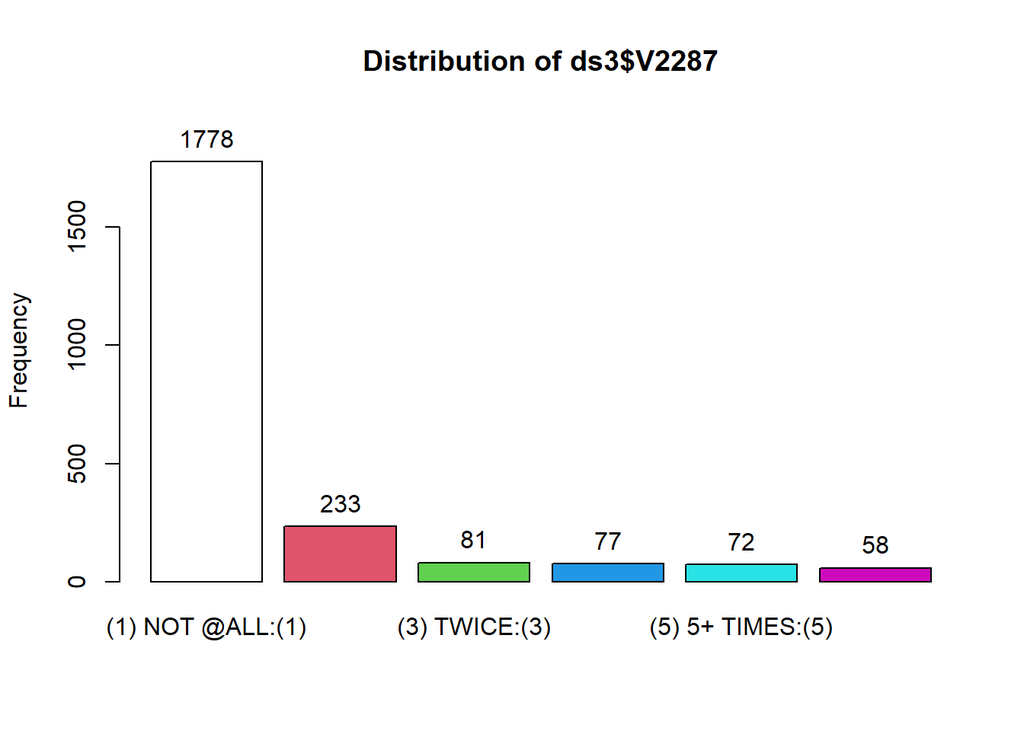

```
## ds3$V2287 :
##                  Frequency   %(NA+) cum.%(NA+)   %(NA-) cum.%(NA-)
## (1) NOT @ALL:(1)      1778     77.3       77.3     79.3       79.3
## (2) ONCE:(2)           233     10.1       87.5     10.4       89.7
## (3) TWICE:(3)           81      3.5       91.0      3.6       93.4
## (4) 3-4TIMES:(4)        77      3.3       94.3      3.4       96.8
## (5) 5+ TIMES:(5)        72      3.1       97.5      3.2      100.0
## NA's                    58      2.5      100.0      0.0      100.0
##   Total               2299    100.0      100.0    100.0      100.0
```

```r
tab1(ds3$V2287, cum.percent = TRUE)
```

### 06610:FRQ CAR THEFT

During the LAST 12 MONTHS, how often have you . . . taken a car that didn’t belong to someone in your family without permission of the owner?

1=“Not At All” 2=“Once” 3=“Twice” 4=“3 or 4 Times” 5=“5 or More Times”

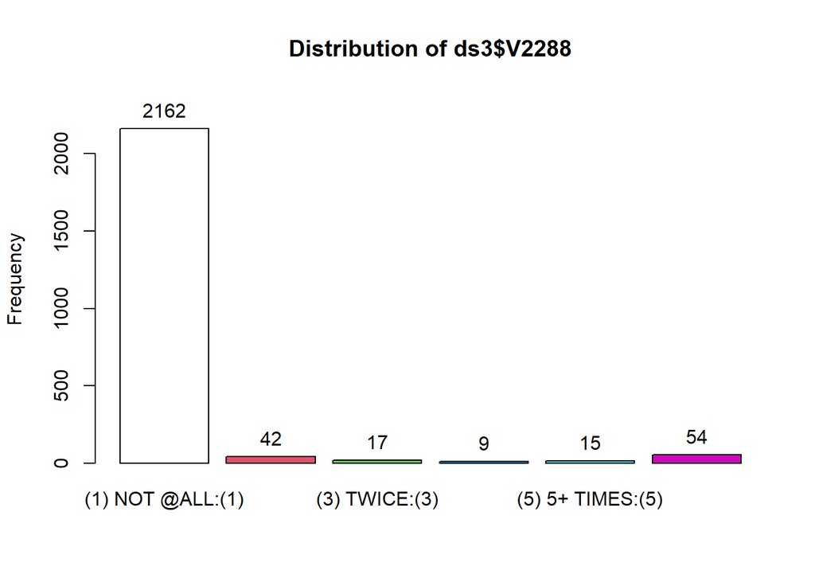

```
## ds3$V2288 :
##                  Frequency   %(NA+) cum.%(NA+)   %(NA-) cum.%(NA-)
## (1) NOT @ALL:(1)      2162     94.0       94.0     96.3       96.3
## (2) ONCE:(2)            42      1.8       95.9      1.9       98.2
## (3) TWICE:(3)           17      0.7       96.6      0.8       98.9
## (4) 3-4TIMES:(4)         9      0.4       97.0      0.4       99.3
## (5) 5+ TIMES:(5)        15      0.7       97.7      0.7      100.0
## NA's                    54      2.3      100.0      0.0      100.0
##   Total               2299    100.0      100.0    100.0      100.0
```

```r
tab1(ds3$V2288, cum.percent = TRUE)
```

### 06620:FRQ STEAL CAR PT

During the LAST 12 MONTHS, how often have you . . . taken part of a car without permission of the owner?

1=“Not At All” 2=“Once” 3=“Twice” 4=“3 or 4 Times” 5=“5 or More Times”

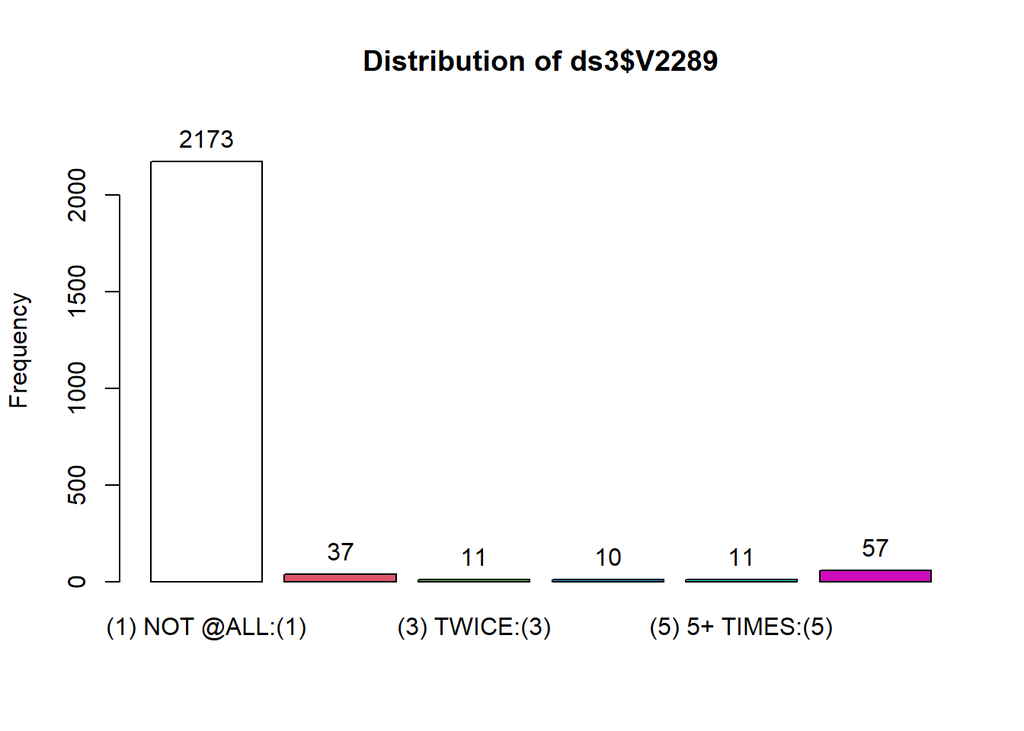

```
## ds3$V2289 :
##                  Frequency   %(NA+) cum.%(NA+)   %(NA-) cum.%(NA-)
## (1) NOT @ALL:(1)      2173     94.5       94.5     96.9       96.9
## (2) ONCE:(2)            37      1.6       96.1      1.7       98.6
## (3) TWICE:(3)           11      0.5       96.6      0.5       99.1
## (4) 3-4TIMES:(4)        10      0.4       97.0      0.4       99.5
## (5) 5+ TIMES:(5)        11      0.5       97.5      0.5      100.0
## NA's                    57      2.5      100.0      0.0      100.0
##   Total               2299    100.0      100.0    100.0      100.0
```

```r
tab1(ds3$V2289, cum.percent = TRUE)
```

### 06630:FRQ TRESPAS BLDG

During the LAST 12 MONTHS, how often have you . . . gone into some house or building when you weren’t supposed to be there?

1=“Not At All” 2=“Once” 3=“Twice” 4=“3 or 4 Times” 5=“5 or More Times”

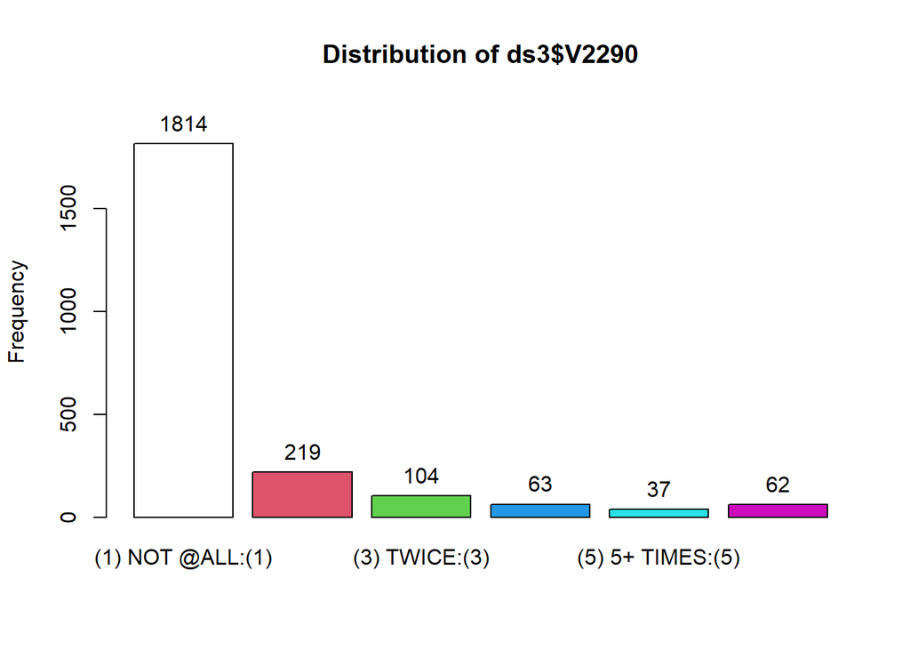

```
## ds3$V2290 :
##                  Frequency   %(NA+) cum.%(NA+)   %(NA-) cum.%(NA-)
## (1) NOT @ALL:(1)      1814     78.9       78.9     81.1       81.1
## (2) ONCE:(2)           219      9.5       88.4      9.8       90.9
## (3) TWICE:(3)          104      4.5       93.0      4.6       95.5
## (4) 3-4TIMES:(4)        63      2.7       95.7      2.8       98.3
## (5) 5+ TIMES:(5)        37      1.6       97.3      1.7      100.0
## NA's                    62      2.7      100.0      0.0      100.0
##   Total               2299    100.0      100.0    100.0      100.0
```

```r
tab1(ds3$V2290, cum.percent = TRUE)
```

### 06640:FRQ ARSON

During the LAST 12 MONTHS, how often have you . . . set fire to someone’s property on purpose?

1=“Not At All” 2=“Once” 3=“Twice” 4=“3 or 4 Times” 5=“5 or More Times”

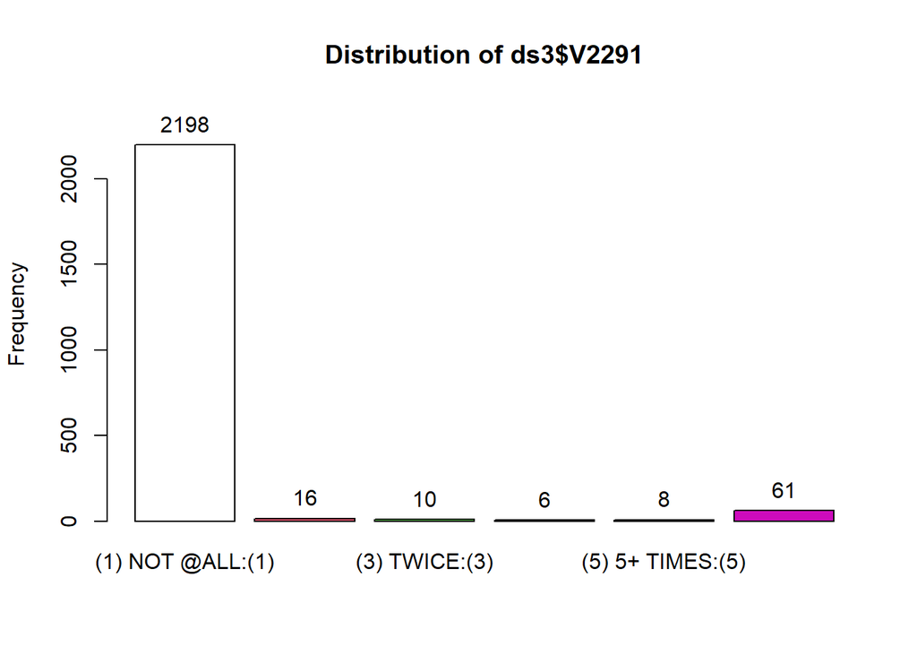

```
## ds3$V2291 :
##                  Frequency   %(NA+) cum.%(NA+)   %(NA-) cum.%(NA-)
## (1) NOT @ALL:(1)      2198     95.6       95.6     98.2       98.2
## (2) ONCE:(2)            16      0.7       96.3      0.7       98.9
## (3) TWICE:(3)           10      0.4       96.7      0.4       99.4
## (4) 3-4TIMES:(4)         6      0.3       97.0      0.3       99.6
## (5) 5+ TIMES:(5)         8      0.3       97.3      0.4      100.0
## NA's                    61      2.7      100.0      0.0      100.0
##   Total               2299    100.0      100.0    100.0      100.0
```

```r
tab1(ds3$V2291, cum.percent = TRUE)
```

### 06650:FRQ DMG SCH PPTY

During the LAST 12 MONTHS, how often have you . . . damaged school property on purpose?

1=“Not At All” 2=“Once” 3=“Twice” 4=“3 or 4 Times” 5=“5 or More Times”

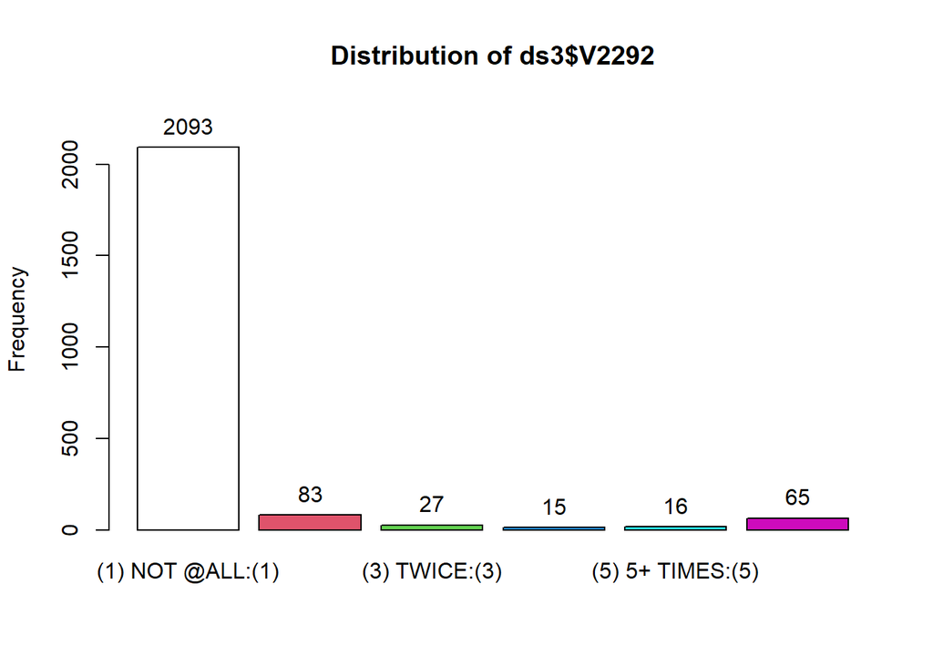

```
## ds3$V2292 :
##                  Frequency   %(NA+) cum.%(NA+)   %(NA-) cum.%(NA-)
## (1) NOT @ALL:(1)      2093     91.0       91.0     93.7       93.7
## (2) ONCE:(2)            83      3.6       94.6      3.7       97.4
## (3) TWICE:(3)           27      1.2       95.8      1.2       98.6
## (4) 3-4TIMES:(4)        15      0.7       96.5      0.7       99.3
## (5) 5+ TIMES:(5)        16      0.7       97.2      0.7      100.0
## NA's                    65      2.8      100.0      0.0      100.0
##   Total               2299    100.0      100.0    100.0      100.0
```

```r
tab1(ds3$V2292, cum.percent = TRUE)
```

### 06660:FRQ DMG WK PRPTY

During the LAST 12 MONTHS, how often have you . . . damaged property at work on purpose?

1=“Not At All” 2=“Once” 3=“Twice” 4=“3 or 4 Times” 5=“5 or More Times”

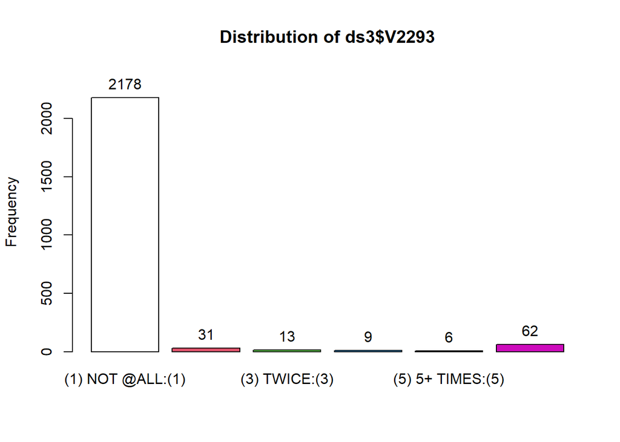

```
## ds3$V2293 :
##                  Frequency   %(NA+) cum.%(NA+)   %(NA-) cum.%(NA-)
## (1) NOT @ALL:(1)      2178     94.7       94.7     97.4       97.4
## (2) ONCE:(2)            31      1.3       96.1      1.4       98.7
## (3) TWICE:(3)           13      0.6       96.7      0.6       99.3
## (4) 3-4TIMES:(4)         9      0.4       97.0      0.4       99.7
## (5) 5+ TIMES:(5)         6      0.3       97.3      0.3      100.0
## NA's                    62      2.7      100.0      0.0      100.0
##   Total               2299    100.0      100.0    100.0      100.0
```

```r
tab1(ds3$V2293, cum.percent = TRUE)
```

## Arrest Variable

### 25880:ARRSTD&TKN 2 POL

During the LAST 12 MONTHS, how often have you . . . been arrested and taken to a police station?

1=“Not At All” 2=“Once” 3=“Twice” 4=“3 or 4 Times” 5=“5 or More Times”

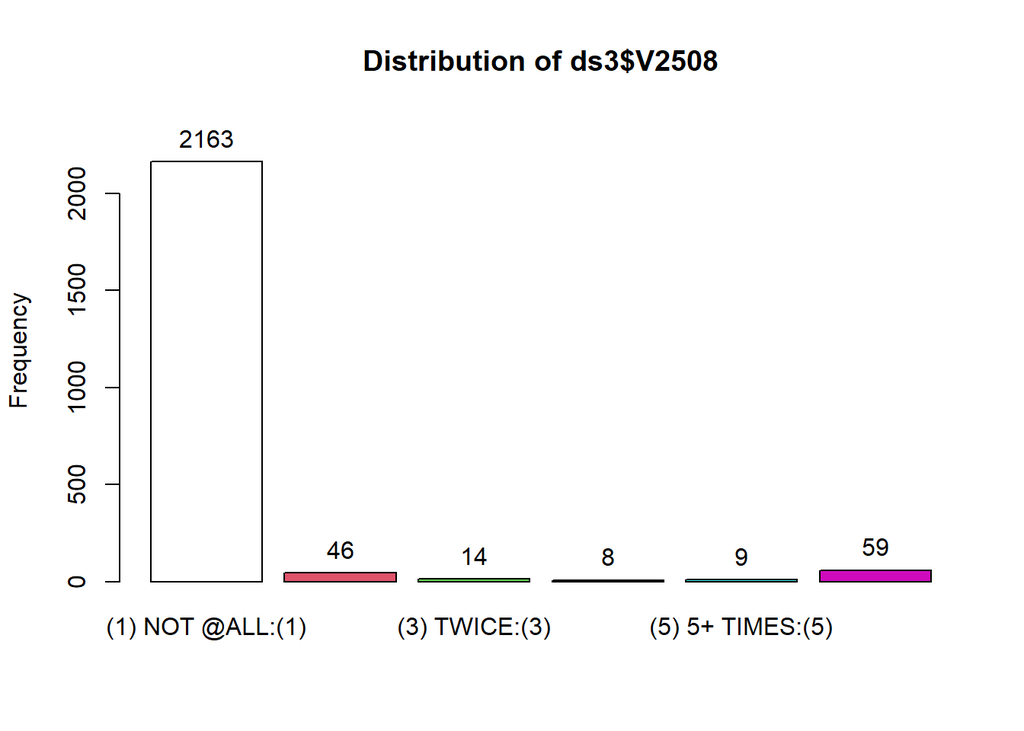

```
## ds3$V2508 :
##                  Frequency   %(NA+) cum.%(NA+)   %(NA-) cum.%(NA-)
## (1) NOT @ALL:(1)      2163     94.1       94.1     96.6       96.6
## (2) ONCE:(2)            46      2.0       96.1      2.1       98.6
## (3) TWICE:(3)           14      0.6       96.7      0.6       99.2
## (4) 3-4TIMES:(4)         8      0.3       97.0      0.4       99.6
## (5) 5+ TIMES:(5)         9      0.4       97.4      0.4      100.0
## NA's                    59      2.6      100.0      0.0      100.0
##   Total               2299    100.0      100.0    100.0      100.0
```

```r
tab1(ds3$V2508, cum.percent = TRUE)
```

## Substance Use Variable

### 00760:EVR SMK CIG,REGL

Have you ever smoked cigarettes?

1=“Never” 2=“Once or twice” 3=“Occasionally but not regularly” 4=“Regularly in the past” 5=“Regularly now”

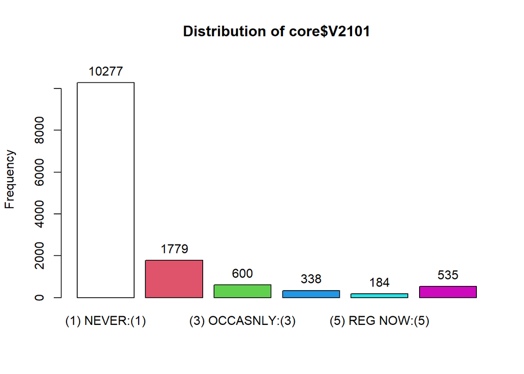

```
## core$V2101 :
##                  Frequency   %(NA+) cum.%(NA+)   %(NA-) cum.%(NA-)
## (1) NEVER:(1)        10277     74.9       74.9     78.0       78.0
## (2) 1-2X:(2)          1779     13.0       87.9     13.5       91.5
## (3) OCCASNLY:(3)       600      4.4       92.3      4.6       96.0
## (4) REG PAST:(4)       338      2.5       94.8      2.6       98.6
## (5) REG NOW:(5)        184      1.3       96.1      1.4      100.0
## NA's                   535      3.9      100.0      0.0      100.0
##   Total              13713    100.0      100.0    100.0      100.0
```

```r
tab1(core$V2101, cum.percent = TRUE)
```

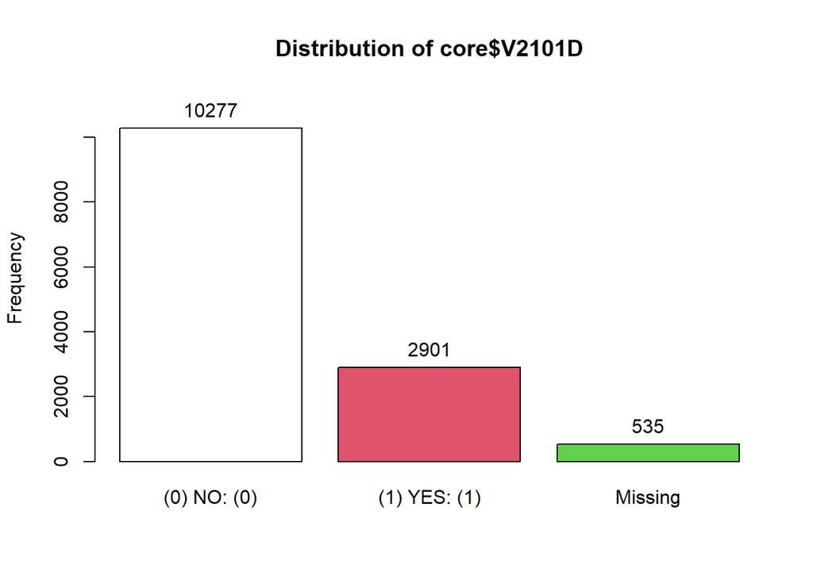

```
## core$V2101D :
##              Frequency   %(NA+) cum.%(NA+)   %(NA-) cum.%(NA-)
## (0) NO: (0)      10277     74.9       74.9       78         78
## (1) YES: (1)      2901     21.2       96.1       22        100
## NA's               535      3.9      100.0        0        100
##   Total          13713    100.0      100.0      100        100
```

```r
tab1(core$V2101D, cum.percent = TRUE)
```

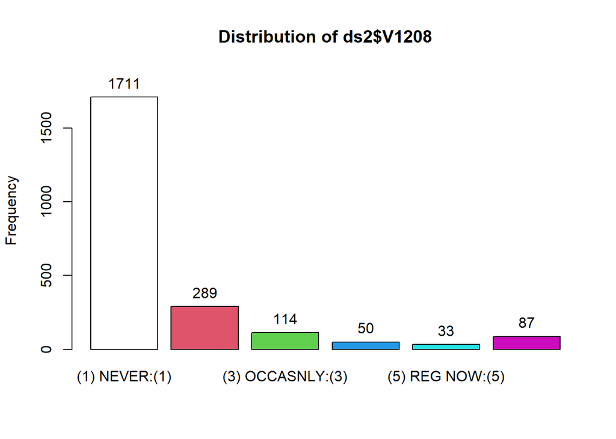

```
## ds2$V1208 :
##                  Frequency   %(NA+) cum.%(NA+)   %(NA-) cum.%(NA-)
## (1) NEVER:(1)         1711     74.9       74.9     77.9       77.9
## (2) 1-2X:(2)           289     12.7       87.6     13.2       91.0
## (3) OCCASNLY:(3)       114      5.0       92.6      5.2       96.2
## (4) REG PAST:(4)        50      2.2       94.7      2.3       98.5
## (5) REG NOW:(5)         33      1.4       96.2      1.5      100.0
## NA's                    87      3.8      100.0      0.0      100.0
##   Total               2284    100.0      100.0    100.0      100.0
```

```r
tab1(ds2$V1208, cum.percent = TRUE)
```

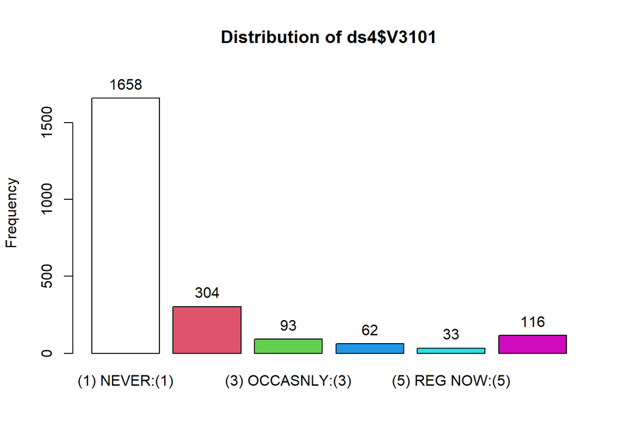

```
## ds4$V3101 :
##                  Frequency   %(NA+) cum.%(NA+)   %(NA-) cum.%(NA-)
## (1) NEVER:(1)         1658     73.2       73.2     77.1       77.1
## (2) 1-2X:(2)           304     13.4       86.6     14.1       91.3
## (3) OCCASNLY:(3)        93      4.1       90.7      4.3       95.6
## (4) REG PAST:(4)        62      2.7       93.4      2.9       98.5
## (5) REG NOW:(5)         33      1.5       94.9      1.5      100.0
## NA's                   116      5.1      100.0      0.0      100.0
##   Total               2266    100.0      100.0    100.0      100.0
```

```r
tab1(ds4$V3101, cum.percent = TRUE)
```

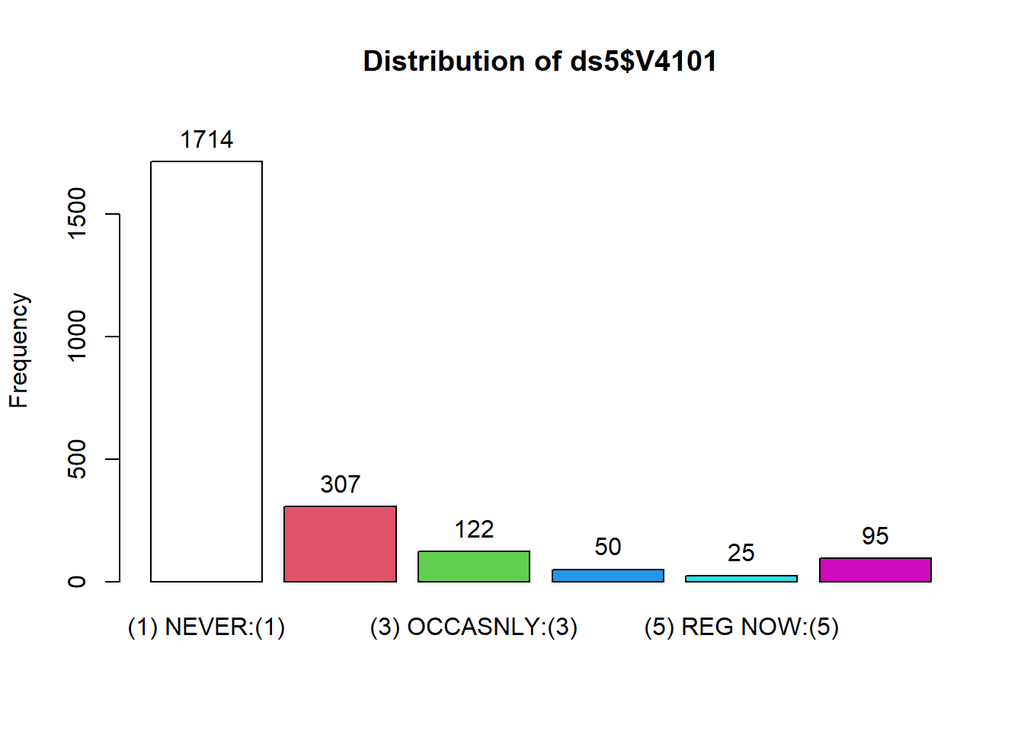

```
## ds5$V4101 :
##                  Frequency   %(NA+) cum.%(NA+)   %(NA-) cum.%(NA-)
## (1) NEVER:(1)         1714     74.1       74.1     77.3       77.3
## (2) 1-2X:(2)           307     13.3       87.4     13.8       91.1
## (3) OCCASNLY:(3)       122      5.3       92.7      5.5       96.6
## (4) REG PAST:(4)        50      2.2       94.8      2.3       98.9
## (5) REG NOW:(5)         25      1.1       95.9      1.1      100.0
## NA's                    95      4.1      100.0      0.0      100.0
##   Total               2313    100.0      100.0    100.0      100.0
```

```r
tab1(ds5$V4101, cum.percent = TRUE)
```

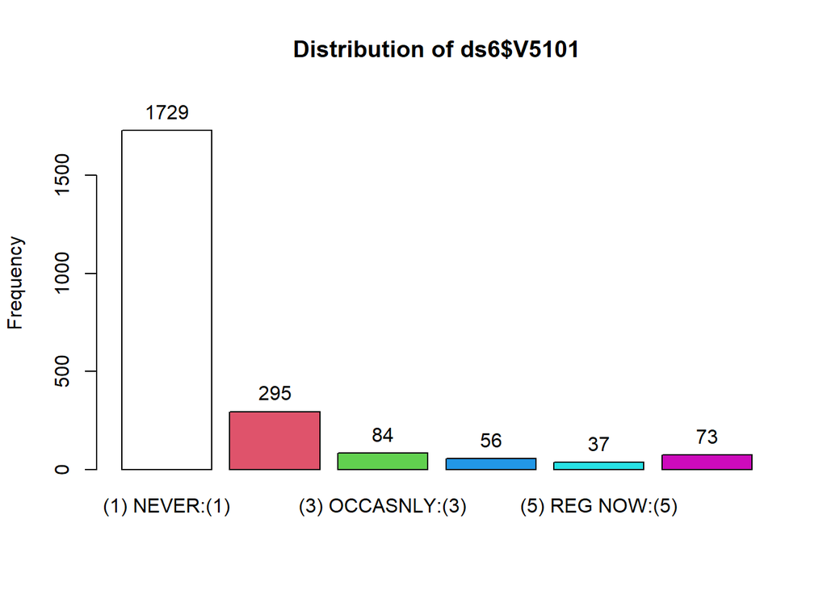

```
## ds6$V5101 :
##                  Frequency   %(NA+) cum.%(NA+)   %(NA-) cum.%(NA-)
## (1) NEVER:(1)         1729     76.0       76.0     78.6       78.6
## (2) 1-2X:(2)           295     13.0       89.0     13.4       92.0
## (3) OCCASNLY:(3)        84      3.7       92.7      3.8       95.8
## (4) REG PAST:(4)        56      2.5       95.2      2.5       98.3
## (5) REG NOW:(5)         37      1.6       96.8      1.7      100.0
## NA's                    73      3.2      100.0      0.0      100.0
##   Total               2274    100.0      100.0    100.0      100.0
```

```r
tab1(ds6$V5101, cum.percent = TRUE)
```

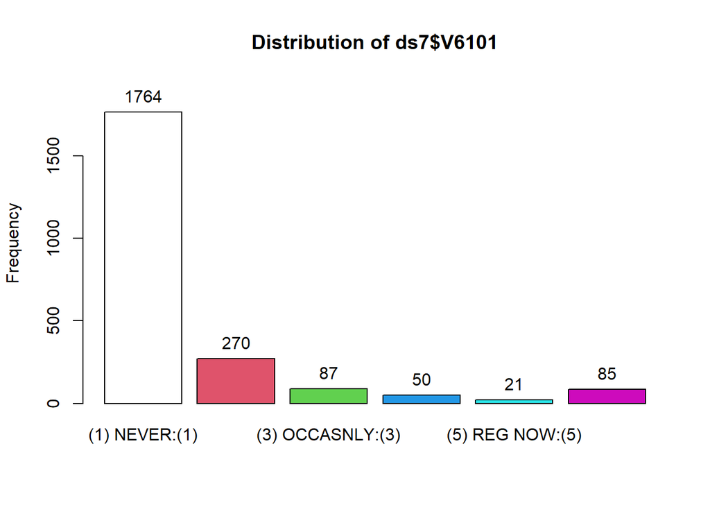

```
## ds7$V6101 :
##                  Frequency   %(NA+) cum.%(NA+)   %(NA-) cum.%(NA-)
## (1) NEVER:(1)         1764     77.5       77.5     80.5       80.5
## (2) 1-2X:(2)           270     11.9       89.3     12.3       92.8
## (3) OCCASNLY:(3)        87      3.8       93.1      4.0       96.8
## (4) REG PAST:(4)        50      2.2       95.3      2.3       99.0
## (5) REG NOW:(5)         21      0.9       96.3      1.0      100.0
## NA's                    85      3.7      100.0      0.0      100.0
##   Total               2277    100.0      100.0    100.0      100.0
```

```r
tab1(ds7$V6101, cum.percent = TRUE)
```